# Seleksjonsdata

Henrik Sørlie

12/14/2021

Her kan man bruke vanlig tekst. Linjeskift skjer automatisk, så for organisasjonens del, (og med tanke på fremtidig bruk av Git), er det en god vane å bruke én linje på én setning. Setningene havner likevel bak hverandre.

Med mindre man hopper over en linje. Da renderes det som nytt avsnitt. Og man kan fortsette å bruke én linje på én setning.

# Dette er en overskrift

## Dette er en overskrift på lavere nivå

### Og så videre

Her kommer det enda mer tekst. I et markdowndokument generelt, og også i RMarkdowndokumenter, kan man angi *kursiv* og **fete typer** lett.

Vi kan også lage bullet-lister:

- Dette er en bullet
- Og dette er en.
- Og enda en

Og her kommer det enda mer tekst. Og så enda en setning. Vi kan bruke redigeringsknappen her oppe til høyre for å få et mer wysiwyg-grensesnitt, slik vi er vant til fra f.eks. word.

## Oversikt over data

Nå kommer det som er mest genialt med RMarkdown. RMarkdown lar oss kombinere tekst og R-kode, og når vi “strikker” dokumentet til HTML, Word eller PDF, så får vi automatisk et dokument der koden er kjørt og resultatene vises som del av dokumentet.

```
##        ID            Gender           AE          Skolepoeng
##  Min.   :  1.0   Min.   :1.00   Min.   :0.000   Min.   :40.84
##  1st Qu.:100.8   1st Qu.:2.00   1st Qu.:4.000   1st Qu.:46.74
##  Median :200.5   Median :2.00   Median :5.000   Median :48.65
##  Mean   :200.5   Mean   :1.82   Mean   :4.647   Mean   :48.82
##  3rd Qu.:300.2   3rd Qu.:2.00   3rd Qu.:6.000   3rd Qu.:50.84
##  Max.   :400.0   Max.   :2.00   Max.   :9.000   Max.   :56.92
##   BS_karakter        Tj_snitt         Skole           Hovedkarakter
##  Min.   : 2.904   Min.   : 5.776   Length:400         Min.   :11.42
##  1st Qu.: 6.037   1st Qu.: 8.631   Class :character   1st Qu.:14.78
##  Median : 6.915   Median : 9.452   Mode  :character   Median :15.70
##  Mean   : 6.860   Mean   : 9.462                      Mean   :15.66
##  3rd Qu.: 7.672   3rd Qu.:10.280                      3rd Qu.:16.52
##  Max.   :11.270   Max.   :13.118                      Max.   :20.04
##      MF_SML
##  Min.   : 5.00
##  1st Qu.: 8.00
##  Median : 8.00
##  Mean   : 8.29
##  3rd Qu.: 9.00
##  Max.   :12.00
```

## Inkludere visualiseringer

Her kan vi plotte dataene, og de dukker da opp i dokumentet.

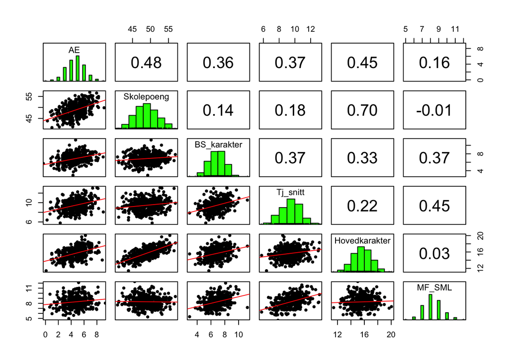

```r
pairs.panels(data[,-c(1, 2, 7)],
             density = FALSE,
             lm = TRUE,
             ellipses = FALSE,
             jiggle = TRUE,
             hist.col = "green")
```